# Упражнения по NumPy

Задание 1. Импортируйте numpy как np и посмотрите версию.

```python
import numpy as np
```

```python
# ваш код здесь
```

Задание 2. Создайте одномерный массив чисел от 0 до 9.

Желаемый результат:

> array([0, 1, 2, 3, 4, 5, 6, 7, 8, 9])

```python
# ваш код здесь
```

Задание 3. Создайте логический массив размером 3 × 3 из всех True.

```python
# ваш код здесь
```

Задание 4. Извлеките все нечетные числа из arr.

Вход:

> arr = np.array([0, 1, 2, 3, 4, 5, 6, 7, 8, 9])

Желаемый результат:

> array([1, 3, 5, 7, 9])

```python
# ваш код здесь
```

Задание 5. Замените все нечетные числа на -1.

Вход:

> arr = np.array([3, 4, 10, 7, 11, 23, 6])

Желаемый результат:

> array([ -1, 4, 10, -1, -1, -1, 6])

```python
# ваш код здесь
```

Задание 6. Преобразование одномерного массива в двухмерный массив с двумя строками.

Вход:

> np.arange(10)

> array([ 0, 1, 2, 3, 4, 5, 6, 7, 8, 9])

```python
# ваш код здесь
```

Задание 7. Выполните стыковку массивов a и b по вертикали.

Вход:

> a = np.arange(10).reshape(2, -1) b = np.repeat(1, 10).reshape(2, -1)

```python
# ваш код здесь
```

Задание 8. Выполните стыковку массивов a и b по горизонтали.

Вход:

> a = np.arange(10).reshape(2, -1) b = np.repeat(1, 10).reshape(2, -1)

Желаемый результат:

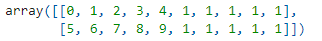

```python
# ваш код здесь
```

Задание 9. Получите все элементы от 5 до 10 в массиве a.

Вход:

> a = np.array([2, 6, 1, 9, 10, 3, 27])

Желаемый результат:

> array([6, 9, 10])

```python
# ваш код здесь
```

Задание 10. Создайте двумерный массив размерностью 5x3, содержащий случайные вещественные числа от 5 до 10.

```python
# ваш код здесь
```

Задание 11. Создайте двумерный массив размерностью 8x8, содержащий случайные целые числа от -10 до 10.

```python
# ваш код здесь
```

Задание 12. Вывести первую строку матрицы из задания 11.

```python
# ваш код здесь
```

Задание 13. Вывести последний столбец матрицы из задания 11.

```python
# ваш код здесь
```

Задание 14. Вывести центральную часть матрицы из задания 11 (размерностью 4х4).

```python
# ваш код здесь
```

Задание 15. Вставить в матрицу из задания 11 строку из минимального элемента перед первой строкой.

```python
# ваш код здесь
```

Задание 16. Вычислить сумму и среднее арифметическое всех элементов матрицы, полученной в задании 15.

```python
# ваш код здесь
```

Задание 17. В одномерном массиве NumPy хранятся имена учеников (имена могут совпадать), а в двумерном массиве – их оценки по 6 предметам (каждая строка соответствует элементу массива с именами). Написать программу, которая будет выводить оценки учеников с заданным именем. Для решения задачи обязательно использовать маску.

Например:

> Имена: array(['Вася','Коля','Петя','Вася','Коля'])

> Оценки:

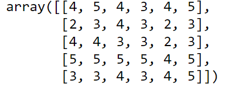

Вводится имя «Вася», должны вывестись 1 и 4 строка матрицы.

```python
# ваш код здесь
```

Задание 18. Сгенерировать два одномерных массива m1 и m2 размерностью 10 (значения от 1 до 10).

```python
# ваш код здесь
```

Задание 19. Сформировать на их основе массив m3, содержащий только те элементы, которые есть либо только в массиве m1, либо только в массиве m2.

```python
# ваш код здесь
```

Задание 20. Заменить в массиве m1 все значения, кратные 3 или 2 на число 1, а остальные – оставить без изменений.

```python
# ваш код здесь
```

Задание 21. Слить массивы m1 и m2 в один и преобразовать получившийся одномерный массив в матрицу размерностью 4х5. Вывести ее на экран.

```python
# ваш код здесь
```